# **MLProjekt**

Łukasz Pyrek

2025-01-11

## **Introduction**

The aim of this project is to analyze the phenomenon of customer churn in the banking sector using the *Bank Customer Churn* dataset. The main objective is to investigate which factors influence a customer’s decision to terminate cooperation with the bank and to develop machine learning models capable of predicting this phenomenon.

## **Loading Libraries**

```r
library(reticulate)
library(rstudioapi)
#setwd(dirname(rstudioapi::getActiveDocumentContext()$path))
```

```python
import pandas as pd
import numpy as np
from scipy import stats

from sklearn.model_selection import cross_validate, train_test_split, GridSearchCV
from sklearn.metrics import make_scorer, accuracy_score, recall_score ,classification_report, confusion_matrix, precision_score, ConfusionMatrixDisplay
from sklearn.ensemble import RandomForestClassifier, AdaBoostClassifier
from sklearn.neighbors import KNeighborsClassifier
from sklearn.svm import SVC
from sklearn.preprocessing import OneHotEncoder, StandardScaler
from sklearn.compose import ColumnTransformer
from sklearn.inspection import permutation_importance

import shap
import dalex as dx

import kaleido
import plotly.graph_objects as go
from IPython.display import Image, display


from imblearn.over_sampling import SMOTE, SMOTENC
from imblearn.pipeline import Pipeline as Pipeline_imb

import matplotlib.pyplot as plt
import seaborn as sns

import warnings
warnings.simplefilter(action='ignore', category=FutureWarning)
```

## **Loading Data and Initial Processing**

Source: https://www.kaggle.com/datasets/shubhammeshram579/bank-customer-churn-prediction

### Loading and Displaying Data

```python
df = pd.read_csv('Churn_Modelling.csv')
```

```r
# R code to show scrollable table
table <- kableExtra::kable_styling(kableExtra::kable(head(py$df, 15), "html"),
                            bootstrap_options = "striped", full_width = FALSE)

scrollable_table <- kableExtra::scroll_box(table, width = "100%", height = "auto")
scrollable_table
```

| RowNumber | CustomerId | Surname | CreditScore | Geography | Gender | Age | Tenure | Balance | NumOfProducts | HasCrCard | IsActiveMember | EstimatedSalary | Exited |
| --- | --- | --- | --- | --- | --- | --- | --- | --- | --- | --- | --- | --- | --- |
| 1 | 15634602 | Hargrave | 619 | France | Female | 42 | 2 | 0.00 | 1 | 1 | 1 | 101348.88 | 1 |
| 2 | 15647311 | Hill | 608 | Spain | Female | 41 | 1 | 83807.86 | 1 | 0 | 1 | 112542.58 | 0 |
| 3 | 15619304 | Onio | 502 | France | Female | 42 | 8 | 159660.80 | 3 | 1 | 0 | 113931.57 | 1 |
| 4 | 15701354 | Boni | 699 | France | Female | 39 | 1 | 0.00 | 2 | 0 | 0 | 93826.63 | 0 |
| 5 | 15737888 | Mitchell | 850 | Spain | Female | 43 | 2 | 125510.82 | 1 | NaN | 1 | 79084.10 | 0 |
| 6 | 15574012 | Chu | 645 | Spain | Male | 44 | 8 | 113755.78 | 2 | 1 | 0 | 149756.71 | 1 |
| 7 | 15592531 | Bartlett | 822 | NA | Male | 50 | 7 | 0.00 | 2 | 1 | 1 | 10062.80 | 0 |
| 8 | 15656148 | Obinna | 376 | Germany | Female | 29 | 4 | 115046.74 | 4 | 1 | 0 | 119346.88 | 1 |
| 9 | 15792365 | He | 501 | France | Male | 44 | 4 | 142051.07 | 2 | 0 | NaN | 74940.50 | 0 |
| 10 | 15592389 | H? | 684 | France | Male | NaN | 2 | 134603.88 | 1 | 1 | 1 | 71725.73 | 0 |
| 11 | 15767821 | Bearce | 528 | France | Male | 31 | 6 | 102016.72 | 2 | 0 | 0 | 80181.12 | 0 |
| 12 | 15737173 | Andrews | 497 | Spain | Male | 24 | 3 | 0.00 | 2 | 1 | 0 | 76390.01 | 0 |
| 13 | 15632264 | Kay | 476 | France | Female | 34 | 10 | 0.00 | 2 | 1 | 0 | 26260.98 | 0 |
| 14 | 15691483 | Chin | 549 | France | Female | 25 | 5 | 0.00 | 2 | 0 | 0 | 190857.79 | 0 |
| 15 | 15600882 | Scott | 635 | Spain | Female | 35 | 7 | 0.00 | 2 | 1 | 1 | 65951.65 | 0 |

Data dimensions:

```python
df.shape
```

```
## (10002, 14)
```

```python
df = df.drop(["RowNumber", "CustomerId", "Surname"], axis = 1)
```

### Missing Data

```python
df.isnull().sum()
```

```
## CreditScore        0
## Geography          1
## Gender             0
## Age                1
## Tenure             0
## Balance            0
## NumOfProducts      0
## HasCrCard          1
## IsActiveMember     1
## EstimatedSalary    0
## Exited             0
## dtype: int64
```

There are a few missing values in the dataset. Due to their small quantity, we remove them.

```python
df = df.dropna()
```

### Data duplications

```python
df.duplicated().sum()
```

```
## 2
```

There are 2 duplicate entries in the dataset, which we remove.

```python
df = df.drop_duplicates()
```

Data dimensions after removing missing values and duplicates.

```python
df.shape
```

```
## (9996, 11)
```

## **EDA**

### Variable descritpion

| **Variable Name** | **Description** |
| --- | --- |
| **Credit Score** | A numerical value representing the customer’s creditworthiness |
| **Geography** | The country of residence of the customer (France, Spain, or Germany) |
| **Gender** | The gender of the customer (Male or Female) |
| **Age** | The age of the customer |
| **Tenure** | The number of years the customer has been with the bank |
| **Balance** | The account balance of the customer |
| **NumOfProducts** | The number of banking products the customer uses |
| **HasCrCard** | Whether the customer has a credit card (1 = Yes, 0 = No) |
| **IsActiveMember** | Whether the customer is an active member (1 = Yes, 0 = No) |
| **EstimatedSalary** | The estimated salary of the customer |
| **Exited** | Whether the customer has left the bank (1 = Yes, 0 = No) |

### Descriptive Statistics

```python
df_describe = df.describe().round(3)
```

```r
# R code to show scrollable table
table <- kableExtra::kable_styling(kableExtra::kable(py$df_describe, "html"),
                            bootstrap_options = "striped", full_width = FALSE)

scrollable_table <- kableExtra::scroll_box(table, width = "100%", height = "auto")
scrollable_table
```

|  | CreditScore | Age | Tenure | Balance | NumOfProducts | HasCrCard | IsActiveMember | EstimatedSalary | Exited |
| --- | --- | --- | --- | --- | --- | --- | --- | --- | --- |
| count | 9996.000 | 9996.000 | 9996.000 | 9996.00 | 9996.000 | 9996.000 | 9996.000 | 9996.00 | 9996.000 |
| mean | 650.503 | 38.921 | 5.013 | 76476.26 | 1.530 | 0.705 | 0.515 | 100106.70 | 0.204 |
| std | 96.625 | 10.488 | 2.892 | 62397.12 | 0.582 | 0.456 | 0.500 | 57513.31 | 0.403 |
| min | 350.000 | 18.000 | 0.000 | 0.00 | 1.000 | 0.000 | 0.000 | 11.58 | 0.000 |
| 25% | 584.000 | 32.000 | 3.000 | 0.00 | 1.000 | 0.000 | 0.000 | 51002.11 | 0.000 |
| 50% | 652.000 | 37.000 | 5.000 | 97173.29 | 1.000 | 1.000 | 1.000 | 100238.11 | 0.000 |
| 75% | 717.250 | 44.000 | 7.250 | 127639.37 | 2.000 | 1.000 | 1.000 | 149400.11 | 0.000 |
| max | 850.000 | 92.000 | 10.000 | 250898.09 | 4.000 | 1.000 | 1.000 | 199992.48 | 1.000 |

| **Variable Name** | **Description** |
| --- | --- |
| **CreditScore** | The average credit score of customers is 650.5. The minimum value is 350, and the maximum is 850. 25% of customers have a credit score below 584, and 75% have a score below 717.25. The standard deviat… |
| **Age** | The average age of customers is about 38.9 years. The youngest customer is 18 years old, and the oldest is 92. 50% of customers are below 37 years old, and 75% are below 44 years old. |
| **Tenure** | The average tenure of customers is 5 years. Tenure ranges from 0 years (no history) to 10 years. Most customers (50%) have a tenure of no more than 5 years. |
| **Balance** | The average account balance is 76,476.26. The minimum balance is 0 (no funds), and the maximum is 250,898.09. 50% of customers have a balance above 97,173.29, indicating a significant number of custom… |
| **NumOfProducts** | The average number of products held is 1.53. Customers hold between 1 and 4 products. 75% of customers have no more than 2 products, indicating a dominance of fewer products. |
| **HasCrCard** | 70.5% of customers have a credit card. The remaining 29.5% do not use credit cards. |
| **IsActiveMember** | 51.5% of customers are active members, while 48.5% are inactive. There is a roughly equal distribution between active and inactive members. |
| **EstimatedSalary** | The average salary is 100,106.70. Salaries range from 11.58 to 199,992.48. 50% of customers earn less than 100,238.11. |
| **Exited** | About 20.4% of customers have left the bank, while 79.6% remain with the bank. |

### Data visualizations

```python
CLR = '#e0240c'
```

#### **Gender**

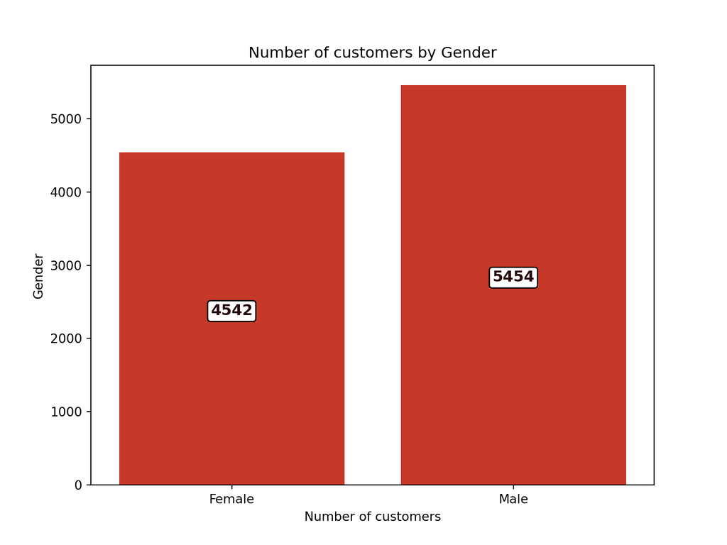

```python
plt.figure(figsize=(8,6))
p = sns.countplot(data=df, x='Gender', orient='h', color=CLR)

for container in p.containers:
    plt.bar_label(container, label_type="center", color="#26090b", fontsize=12, weight='bold', padding=6,
                  bbox={"boxstyle": "round", "pad": 0.2, "facecolor": 'white', "alpha": 1})

plt.title('Number of customers by Gender')
plt.xlabel('Number of customers')
plt.ylabel('Gender')
plt.show()
```

#### **Geography**

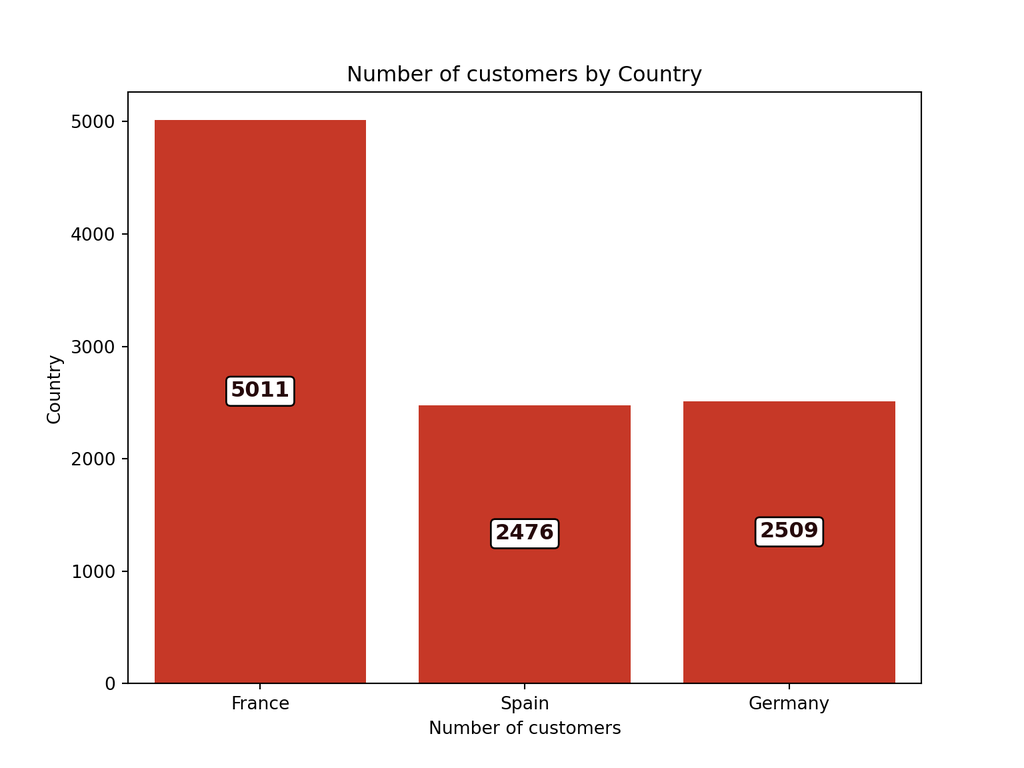

```python
plt.figure(figsize=(8,6))
p = sns.countplot(data=df, x='Geography', orient='h', color=CLR)

for container in p.containers:
    plt.bar_label(container, label_type="center", color="#26090b", fontsize=12, weight='bold', padding=6,
                  bbox={"boxstyle": "round", "pad": 0.2, "facecolor": 'white', "alpha": 1})

plt.title('Number of customers by Country')
plt.xlabel('Number of customers')
plt.ylabel('Country')
plt.show()
```